# Atividades - Escolas Gabarito

2024-10-03

[figure not shown]

Você acabou de conseguir um novo emprego como analista de dados para o estado de Massachusetts, trabalhando no Departamento de Educação Elementar e Secundária (ou DEES, para abreviar!). O DEES supervisiona o sistema de educação pública do estado. Uma responsabilidade do DEES é garantir que todas as crianças tenham uma educação de qualidade – uma educação em que encontrem professores experientes, tenham acesso a uma abundância de recursos e, em última análise, formem-se tendo cumprido todos os requisitos do estado. Suas habilidades em SQL têm um papel a desempenhar nesses objetivos elevados!

As informações estão contidas no banco de dados `dees.db` BAIXAR

## Schema

Em Massachusetts, a educação pública é delegada aos distritos, um tipo de governo escolar frequentemente associado a uma cidade individual. Esses distritos, por sua vez, contêm muitas escolas individuais. Considere o diagrama de entidade-relacionamento abaixo, que codifica a relação entre distritos, escolas e outros dados que o DEES recolhe.

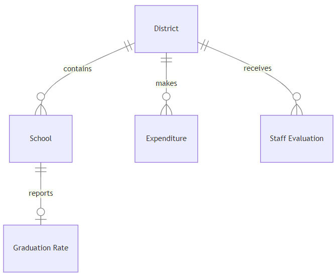

Dentro de `dese.db`, você encontrará diversas tabelas que implementam os relacionamentos descritos no diagrama acima. Clique nos menus suspensos abaixo para saber mais sobre o esquema de cada tabela individual.

**tabela districts** (distritos)**

A tabela districts contém as seguintes colunas:

- `id`: identifica o id do distrito
- `name`: o nome do distrito
- `type`: que denota o tipo de distrito. Em Massachusetts, existem distritos escolares públicos (denominados “Public School District”) e distritos autônomos (denotados “Charter District”). Não há necessidade de entender a diferença entre os dois!
- `city`: a cidade em que o distrito está localizado
- `state`: o estado em que o distrito está localizado
- `zip`: o ZIP (cep) do distrito

**tabela schools** (escolas)**

- `id`: identifica o id da escola
- `name`: o nome da escola
- `type`: o tipo de escola (“Public School” ou “Charter School”)
- `city`: a cidade em que a escola está localizada
- `state`: o estado em que a escola está localizada
- `zip`: o ZIP (cep) da escola

**tabela graduation_rates** (taxas de graduação)**

A tabela graduation_rates contém as seguintes colunas:

- `id`: identifica o id da taxa de graduação
- `school_id`: o ID da escola associada à taxa de graduação
- `graduated`: percentual de alunos,0-100, que se formaram no tempo certo
- `dropped`: percentual de alunos,0-100, que se formaram no tempo certo
- `excluded`: percentual de alunos,0-100, que foram expulsos

**tabela expenditures** (gastos)**

- `id`: identifica o id do gasto
- `district_id`: id do distrito associado ao gasto
- `pupils`: número de alunos que frequentam as escolas do distrito
- `per_pupil_expenditure`: a quantia de dinheiro gasta por aluno que frequenta escolas no distrito

**tabela staff_evaluations** (avaliações das equipes)**

A tabela staff_evaluations contém as seguintes colunas:

- `id`: identifica o id do relatório de avaliação
- `district_id`: id do distrito associado à avaliação
- `evaluated`: porcentagem de avaliações das equipes dos distritos
- `exemplary`: é a porcentagem de avaliações que marcaram as equipes do distrito como “exemplares” `exemplary`
- `proficient`: é a porcentagem de avaliações que marcaram as equipes do distrito como “proficientes” `proficient`
- `needs_improvement`: é a porcentagem de avaliações que marcaram as equipes do distrito como “precisam de melhoria” `needs_improvement`
- `unsatisfactory`: é a porcentagem de avaliações que marcaram as equipes do distrito como “insatisfatória” `unsatisfactory`

OBS: Alguns dos relacionamentos do banco de dados podem ser descritos por uma tabela única. Mas você deve trabalhar com o banco de dados que a equipe usa!

## Problema para resolver

Para cada uma das perguntas a seguir, você deve escrever uma única query SQL que produza os resultados especificados por cada problema. Sua resposta deve assumir a forma de uma única consulta SQL.

1. Seu colega está preparando um mapa de todas as **escolas públicas** de Massachusetts. Escreva uma *query* SQL para encontrar os nomes e cidades de todas as escolas públicas de Massachusetts. OBS: Lembre que nem todas as escolas na tabela `schools` são consideradas escolas públicas.
2. Sua equipe está trabalhando no arquivamento de dados antigos. Escreva uma *query* SQL para encontrar os nomes dos distritos que não estão mais operacionais. OBS:Distritos que não estão mais operacionais tem o “(non-op)” no final de seu nome.
3. O Legislativo de Massachusetts gostaria de saber quanto dinheiro, em média, os distritos gastaram por aluno no ano passado. Escreva uma consulta SQL para encontrar o gasto médio por aluno. Nomeie a coluna como “Despesas Médias por Aluno do Distrito”.
   - Observe que a coluna `per_pupil_expenditure` na tabela de `expenditures` contém o valor médio, por aluno, que cada distrito gastou no ano passado. Encontre a média deste conjunto de médias, ponderando cada distrito de forma igual, independentemente do seu tamanho.
4. Algumas cidades têm mais escolas públicas do que outras. Escreva uma *query* SQL para encontrar as 10 cidades com mais escolas públicas. Sua consulta deve retornar os nomes das cidades e o número de escolas públicas dentro delas, ordenados do maior para o menor número de escolas públicas. Se duas cidades tiverem o mesmo número de escolas públicas, ordene-as em ordem alfabética.
5. O DEES gostaria que você determinasse em quais cidades poderiam ser necessárias escolas públicas adicionais. Escreva uma *query* para encontrar cidades com 3 ou menos escolas públicas (“Public Schools”). Sua consulta deve retornar os nomes das cidades e o número de escolas públicas dentro delas, ordenados do maior para o menor. Se duas cidades tiverem o mesmo número de escolas públicas, ordene-as de forma alfabética.
6. O DEES quer avaliar quais escolas alcançaram uma taxa de graduação de 100%. Escreva uma *query* SQL para encontrar os nomes das escolas (públicas ou charter!) que relataram uma taxa de graduação de 100%.
7. O DEESE está preparando um relatório sobre as escolas do distrito escolar de Cambridge. Escreva uma *query* SQL para encontrar os nomes das escolas (públicas ou charter!) no distrito escolar de Cambridge. Tenha em mente que Cambridge, a cidade, contém alguns distritos escolares, mas o DESE está interessado no distrito cujo nome é “Cambridge”.
8. Um pai deseja enviar seu filho para um distrito que tenha muitos alunos. Escreva uma *query* SQL para exibir os nomes de todos os distritos escolares e o número de alunos matriculados em cada um.
9. Outro pai deseja enviar seu filho para um distrito com poucos alunos. Escreva uma *query* SQL para encontrar o nome (ou nomes) do(s) distrito(s) escolar(es) com o menor número de alunos. Informe apenas o(s) nome(s).
10. Em Massachusetts, as despesas do distrito escolar são em parte determinadas pelos impostos locais sobre valores de propriedade (por exemplo, casa). Escreva uma *query* SQL para encontrar os 10 distritos escolares públicos com os maiores gastos por aluno. A sua consulta deverá devolver os nomes dos distritos e as despesas por aluno de cada um.
11. Existe uma relação entre despesas escolares e taxas de graduação? Escreva uma *query* SQL para exibir os nomes das escolas, suas despesas por aluno e sua taxa de graduação. Classifique as escolas da maior para a menor despesa por aluno. Se duas escolas tiverem a mesma despesa por aluno, ordene por nome da escola. (Assuma que a despesa por aluno de cada escola é a mesma que o seu distrito gasta como um todo).
12. Um pai pede conselhos sobre como encontrar os melhores distritos escolares públicos em Massachusetts. Escreva uma *query* SQL para encontrar distritos escolares públicos com gastos por aluno acima da média e uma porcentagem acima da média de professores classificados como “exemplares”. A sua consulta deverá devolver os nomes dos distritos, juntamente com as suas despesas por aluno e a percentagem de professores classificados como exemplares. Classifique os resultados primeiro pela percentagem de professores classificados como exemplares (de alto a baixo), depois pela despesa por aluno (de alto a baixo).

## RESPOSTAS

**Ver**

##### 1 Seu colega está preparando um mapa de todas as **escolas públicas** de Massachusetts. Escreva uma *query* SQL para encontrar os nomes e cidades de todas as escolas públicas de Massachusetts. OBS: Lembre que nem todas as escolas na tabela `schools` são consideradas escolas públicas.

```sql
SELECT "name","city" FROM "schools" WHERE "type" = "Public School";
```

**Ver resultado**

|  | name | city |
| --- | --- | --- |
| 1 | Abington Early Education Program | Abington |
| 2 | Abington High | Abington |
| 3 | Abington Middle School | Abington |
| 4 | Beaver Brook Elementary | Abington |
| 5 | Woodsdale Elementary School | Abington |
| 6 | Acton-Boxborough Regional High | Acton |
| 7 | Blanchard Memorial School | Boxborough |
| 8 | C.T. Douglas Elementary School | Acton |
| 9 | Carol Huebner Early Childhood Program | Acton |
| 10 | Luther Conant School | Acton |

[output cut: 1751 more lines]

##### 2 Sua equipe está trabalhando no arquivamento de dados antigos. Escreva uma *query* SQL para encontrar os nomes dos distritos que não estão mais operacionais. OBS:Distritos que não estão mais operacionais tem o “(non-op)” no final de seu nome.

```sql
SELECT "name" FROM "districts" WHERE "name" LIKE '%non-op%';
```

**Ver resultado**

|  | name |
| --- | --- |
| 1 | Acton (non-op) |
| 2 | Adams (non-op) |
| 3 | Alford (non-op) |
| 4 | Aquinnah (non-op) |
| 5 | Ashburnham (non-op) |
| 6 | Ashby (non-op) |
| 7 | Ashfield (non-op) |
| 8 | Athol (non-op) |
| 9 | Ayer (non-op) |
| 10 | Barre (non-op) |

[output cut: 111 more lines]

##### 3 O Legislativo de Massachusetts gostaria de saber quanto dinheiro, em média, os distritos gastaram por aluno no ano passado. Escreva uma consulta SQL para encontrar o gasto médio por aluno. Nomeie a coluna como “Despesas Médias por Aluno do Distrito”. - Observe que a coluna `per_pupil_expenditure` na tabela de `expenditures` contém o valor médio, por aluno, que cada distrito gastou no ano passado. Encontre a média deste conjunto de médias, ponderando cada distrito de forma igual, independentemente do seu tamanho.

```sql
SELECT AVG("per_pupil_expenditure") AS "Média por estudante" FROM "expenditures"
```

**Ver resultado**

|  | Média por estudante |
| --- | --- |
| 1 | 19528.99002525253 |

```sql
SELECT "city",COUNT("id") AS 'Total de escolas' FROM "schools" GROUP BY "city"
ORDER BY "Total de escolas" DESC, "city" ASC
LIMIT 10;
```

**Ver resultado**

|  | city | Total de escolas |
| --- | --- | --- |
| 1 | Springfield | 71 |
| 2 | Worcester | 49 |
| 3 | Dorchester | 29 |
| 4 | Lawrence | 29 |
| 5 | Lowell | 29 |
| 6 | Lynn | 28 |
| 7 | New Bedford | 28 |
| 8 | Brockton | 25 |
| 9 | Cambridge | 20 |
| 10 | Fall River | 20 |

##### 5 O DEES gostaria que você determinasse em quais cidades poderiam ser necessárias escolas públicas adicionais. Escreva uma *query* para encontrar cidades com 3 ou menos escolas públicas (“Public Schools”). Sua consulta deve retornar os nomes das cidades e o número de escolas públicas dentro delas, ordenados do maior para o menor. Se duas cidades tiverem o mesmo número de escolas públicas, ordene-as de forma alfabética.

```sql
SELECT "city","Total de escolas","type" FROM (
    SELECT "city",COUNT("id") AS 'Total de escolas',"type"  FROM "schools" WHERE "type" = "Public School" GROUP BY "city"
    ) WHERE ("Total de escolas" <= 3) ORDER BY "Total de escolas" DESC,"city" ASC;
```

**Ver resultado**

|  | city | Total de escolas | type |
| --- | --- | --- | --- |
| 1 | Ashburnham | 3 | Public School |
| 2 | Athol | 3 | Public School |
| 3 | Barre | 3 | Public School |
| 4 | Charlestown | 3 | Public School |
| 5 | Chestnut Hill | 3 | Public School |
| 6 | Clinton | 3 | Public School |
| 7 | Dalton | 3 | Public School |
| 8 | Dartmouth | 3 | Public School |
| 9 | Dighton | 3 | Public School |
| 10 | Dover | 3 | Public School |

[output cut: 191 more lines]

##### 6 O DEES quer avaliar quais escolas alcançaram uma taxa de graduação de 100%. Escreva uma *query* SQL para encontrar os nomes das escolas (públicas ou charter!) que relataram uma taxa de graduação de 100%.

```sql
SELECT "name" FROM "schools" WHERE "id" IN (
   SELECT "school_id" FROM "graduation_rates" WHERE "graduated" = 100);
```

**Ver resultado**

|  | name |
| --- | --- |
| 1 | Tahanto Regional High |
| 2 | O'Bryant School of Math &amp; Science |
| 3 | Cohasset High School |
| 4 | Global Learning Charter Public School |
| 5 | Bromfield |
| 6 | Pioneer Valley Regional |
| 7 | Sizer School: A North Central Charter Essential School |
| 8 | Upper Cape Cod Vocational Technical |
| 9 | Weston High |

##### 7 O DEESE está preparando um relatório sobre as escolas do distrito escolar de Cambridge. Escreva uma *query* SQL para encontrar os nomes das escolas (públicas ou charter!) no distrito escolar de Cambridge. Tenha em mente que Cambridge, a cidade, contém alguns distritos escolares, mas o DESE está interessado no distrito cujo nome é “Cambridge”.

```sql
SELECT "name" FROM "schools" WHERE "district_id" = (
  SELECT "id" FROM "districts" WHERE "name" = "Cambridge");
```

**Ver resultado**

|  | name |
| --- | --- |
| 1 | Amigos School |
| 2 | Cambridge Rindge and Latin |
| 3 | Cambridge Street Upper School |
| 4 | Cambridgeport |
| 5 | Fletcher/Maynard Academy |
| 6 | Graham and Parks |
| 7 | Haggerty |
| 8 | John M Tobin |
| 9 | Kennedy-Longfellow |
| 10 | King Open |

[output cut: 7 more lines]

##### 8 Um pai deseja enviar seu filho para um distrito que tenha muitos alunos. Escreva uma *query* SQL para exibir os nomes de todos os distritos escolares e o número de alunos matriculados em cada um.

O expenditure não tem registros dos distritos que não estão mais funcionando, usando o LEFT JOIN fica fácil de visualizar essa situação:

```sql
SELECT * FROM "districts"
LEFT JOIN "expenditures"
ON "expenditures"."district_id" = "districts"."id";
```

**Ver resultado**

|  | id | name | type | city | state | zip | id | district_id | pupils | per_pupil_expenditure |
| --- | --- | --- | --- | --- | --- | --- | --- | --- | --- | --- |
| 1 | 1 | Abby Kelley Foster Charter Public (District) | Charter District | Worcester | MA | 01606 | 1 | 1 | 1424 | 16853.85 |
| 2 | 2 | Abington | Public School District | Abington | MA | 02351 | 2 | 2 | 2244 | 16143.23 |
| 3 | 3 | Academy Of the Pacific Rim Charter Public (District) | Charter District | Hyde Park | MA | 02136 | 3 | 3 | 539 | 21216.47 |
| 4 | 4 | Acton (non-op) | Public School District | Acton | MA | 01720 |  |  |  |  |
| 5 | 5 | Acton-Boxborough | Public School District | Acton | MA | 01720 | 4 | 5 | 5345 | 18957.61 |
| 6 | 6 | Acushnet | Public School District | Acushnet | MA | 02743 | 5 | 6 | 1235 | 14908.37 |
| 7 | 7 | Adams (non-op) | Public School District | Cheshire | MA | 01225 |  |  |  |  |
| 8 | 8 | Advanced Math and Science Academy Charter (District) | Charter District | Marlborough | MA | 01752 | 6 | 8 | 964 | 16675.46 |
| 9 | 9 | Agawam | Public School District | Feeding Hills | MA | 01030 | 7 | 9 | 3629 | 19689.66 |
| 10 | 10 | Alford (non-op) | Public School District | Sheffield | MA | 01257 |  |  |  |  |

[output cut: 510 more lines]

Para ver a *query* correta (sem valores faltantes) usamos o JOIN:

```sql
SELECT * FROM "districts"
JOIN "expenditures"
ON "expenditures"."district_id" = "districts"."id";
```

**Ver resultado**

|  | id | name | type | city | state | zip | id | district_id | pupils | per_pupil_expenditure |
| --- | --- | --- | --- | --- | --- | --- | --- | --- | --- | --- |
| 1 | 1 | Abby Kelley Foster Charter Public (District) | Charter District | Worcester | MA | 01606 | 1 | 1 | 1424 | 16853.85 |
| 2 | 2 | Abington | Public School District | Abington | MA | 02351 | 2 | 2 | 2244 | 16143.23 |
| 3 | 3 | Academy Of the Pacific Rim Charter Public (District) | Charter District | Hyde Park | MA | 02136 | 3 | 3 | 539 | 21216.47 |
| 4 | 5 | Acton-Boxborough | Public School District | Acton | MA | 01720 | 4 | 5 | 5345 | 18957.61 |
| 5 | 6 | Acushnet | Public School District | Acushnet | MA | 02743 | 5 | 6 | 1235 | 14908.37 |
| 6 | 8 | Advanced Math and Science Academy Charter (District) | Charter District | Marlborough | MA | 01752 | 6 | 8 | 964 | 16675.46 |
| 7 | 9 | Agawam | Public School District | Feeding Hills | MA | 01030 | 7 | 9 | 3629 | 19689.66 |
| 8 | 11 | Alma del Mar Charter School (District) | Charter District | New Bedford | MA | 02746 | 8 | 11 | 788 | 16667.96 |
| 9 | 12 | Amesbury | Public School District | Amesbury | MA | 01913 | 9 | 12 | 2037 | 19883.64 |
| 10 | 13 | Amherst | Public School District | Amherst | MA | 01002 | 10 | 13 | 1135 | 26345.29 |

[output cut: 386 more lines]

##### 9 Outro pai deseja enviar seu filho para um distrito com poucos alunos. Escreva uma *query* SQL para encontrar o nome (ou nomes) do(s) distrito(s) escolar(es) com o menor número de alunos. Informe apenas o(s) nome(s).

Fazendo a busca com os 3 distritos com os menores números de alunos:

```sql
SELECT * FROM "districts"
JOIN "expenditures"
ON "expenditures"."district_id" = "districts"."id"
ORDER BY "pupils" ASC LIMIT 3;
```

**Ver resultado**

|  | id | name | type | city | state | zip | id | district_id | pupils | per_pupil_expenditure |
| --- | --- | --- | --- | --- | --- | --- | --- | --- | --- | --- |
| 1 | 404 | Savoy | Public School District | Savoy | MA | 01256 | 312 | 404 | 64 | 21564.49 |
| 2 | 250 | Lowell Middlesex Academy Charter (District) | Charter District | Lowell | MA | 01852 | 190 | 250 | 84 | 24167.84 |
| 3 | 392 | Rowe | Public School District | Rowe | MA | 01367 | 305 | 392 | 85 | 27629.9 |

```sql
SELECT "districts".name,"expenditures"."per_pupil_expenditure" FROM
"expenditures"
JOIN "districts" ON
"districts".id = "expenditures".district_id
ORDER BY "expenditures".per_pupil_expenditure DESC LIMIT 10;
```

**Ver resultado**

|  | name | per_pupil_expenditure |
| --- | --- | --- |
| 1 | Provincetown | 41318.9 |
| 2 | Cambridge | 35113.7 |
| 3 | Martha's Vineyard Charter Public School (District) | 35079.24 |
| 4 | Martha's Vineyard | 34611.23 |
| 5 | Minuteman Regional Vocational Technical | 32814.39 |
| 6 | Wellfleet | 32788.2 |
| 7 | Truro | 32245.03 |
| 8 | Orleans | 31703.4 |
| 9 | Weston | 30295.95 |
| 10 | Tisbury | 29598.7 |

```sql
 SELECT
  "schools"."district_id",
  "schools"."id" AS 'school_id',
  "schools"."name",
  "per_pupil_expenditure" ,
  "graduation_rates".graduated
FROM "schools"
JOIN "expenditures"
ON "schools"."district_id" = "expenditures".district_id
JOIN "graduation_rates"
ON "schools"."id" = "graduation_rates"."school_id"
ORDER BY "per_pupil_expenditure";
```

**Ver resultado**

|  | district_id | school_id | name | per_pupil_expenditure | graduated |
| --- | --- | --- | --- | --- | --- |
| 1 | 176 | 642 | Greater Commonwealth Virtual School | 10043.6 | 47.6 |
| 2 | 450 | 1559 | TEC Connections Academy Commonwealth Virtual School | 10564.26 | 47.9 |
| 3 | 127 | 483 | Dracut Senior High | 13660.99 | 96.1 |
| 4 | 436 | 1521 | Springfield International Charter School | 13675.68 | 97 |
| 5 | 27 | 76 | Atlantis Charter School | 14406.56 | 96.5 |
| 6 | 277 | 985 | Melrose High | 14565.67 | 97 |
| 7 | 489 | 1680 | West Bridgewater Junior/Senior | 14595.33 | 96.3 |
| 8 | 71 | 299 | Bridgewater-Raynham Regional | 14606.21 | 96.2 |
| 9 | 325 | 1148 | North Attleboro High | 14664.85 | 95.1 |
| 10 | 20 | 63 | Oakmont Regional High School | 14920.21 | 95.9 |

[output cut: 381 more lines]

O JOIN deve ficar antes das cláusulas WHERE, então primeiro criamos o JOIN das duas tabelas, e depois colocamos as condições abaixo.

```sql
SELECT "districts"."name", "expenditures"."per_pupil_expenditure","staff_evaluations"."exemplary" FROM "districts"
JOIN "expenditures" ON "districts"."id" = "expenditures"."district_id"
JOIN "staff_evaluations" ON "districts"."id" = "staff_evaluations".district_id
WHERE "districts"."type" = "Public School District"
AND "expenditures"."per_pupil_expenditure" >
    (SELECT AVG("per_pupil_expenditure") FROM "expenditures")
AND
    ("staff_evaluations".exemplary >
        (SELECT AVG("exemplary") FROM "staff_evaluations")
    );
```

**Ver resultado**

|  | name | per_pupil_expenditure | exemplary |
| --- | --- | --- | --- |
| 1 | Amherst-Pelham | 24555.36 | 19.2 |
| 2 | Andover | 20941.36 | 23.7 |
| 3 | Assabet Valley Regional Vocational Technical | 20447.01 | 21.3 |
| 4 | Berkshire Hills | 23998.57 | 29.5 |
| 5 | Blackstone Valley Regional Vocational Technical | 21509.51 | 31.5 |
| 6 | Bourne | 20294.55 | 24.4 |
| 7 | Brewster | 25117.33 | 52.5 |
| 8 | Bristol County Agricultural | 21286.32 | 18.6 |
| 9 | Cambridge | 35113.7 | 30.3 |
| 10 | Canton | 20012.55 | 18.2 |

[output cut: 55 more lines]